# This Guy, Elmore, Made This

# AAPL: Key Financial Ratios

### Financial Ratios

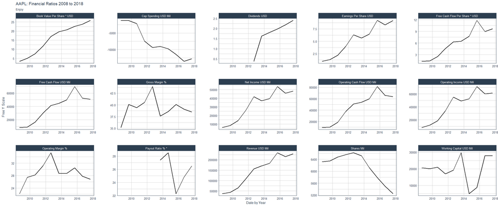

### Profitability Ratios

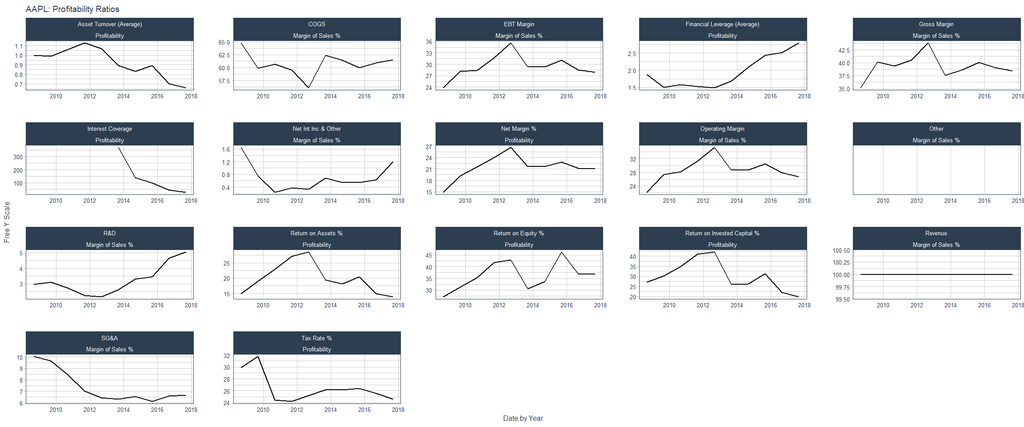

### Growth Ratios

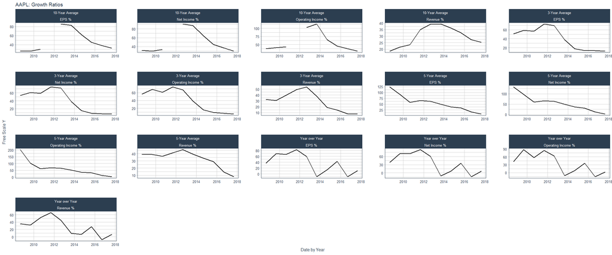

### Cash Flow Ratios

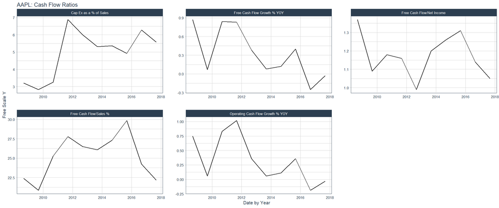

### Financial Health Ratios

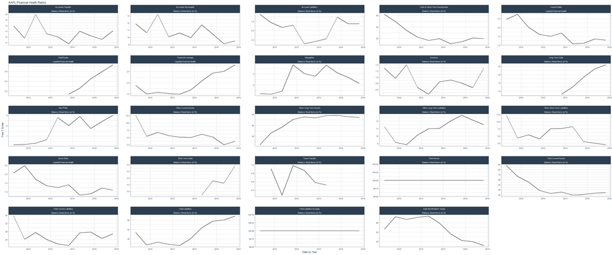

### Efficiency Ratios

[figure not shown]

### Valuation Ratios

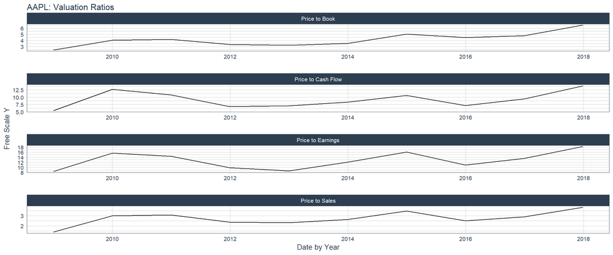

# Data Tables

### Stock Price data

| AAPL.Open | AAPL.High | AAPL.Low | AAPL.Close | AAPL.Volume | AAPL.Adjusted |
| --- | --- | --- | --- | --- | --- |
| 12.327143 | 12.368571 | 11.7 | 11.971429 | 309579900 | 8.073009 |
| 12.007143 | 12.278571 | 11.974286 | 12.237143 | 211815100 | 8.252192 |
| 12.252857 | 12.314285 | 12.057143 | 12.15 | 208685400 | 8.193427 |
| 12.28 | 12.361428 | 12.182858 | 12.21 | 199276700 | 8.233888 |
| 12.35 | 13.282857 | 12.164286 | 13.224286 | 837324600 | 8.917878 |
| 13.535714 | 13.971429 | 13.35 | 13.857142 | 738220000 | 9.344647 |
| 13.705714 | 13.825714 | 13.585714 | 13.685715 | 360063200 | 9.229047 |
| 13.512857 | 13.58 | 13.318571 | 13.517143 | 328172600 | 9.115368 |
| 13.668571 | 13.892858 | 13.635715 | 13.871428 | 311019100 | 9.354283 |
| 13.937143 | 13.942857 | 13.545714 | 13.564285 | 411565000 | 9.147159 |

[output cut: 2886 more lines]

# Economic Data

### Consumer Price Index

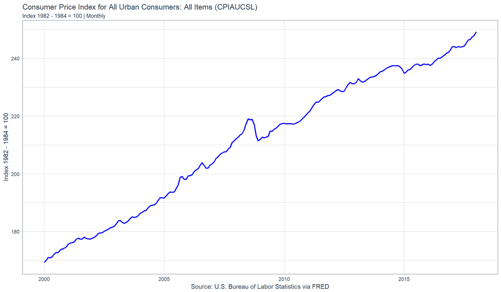

### Federal Reserve Balance Sheet

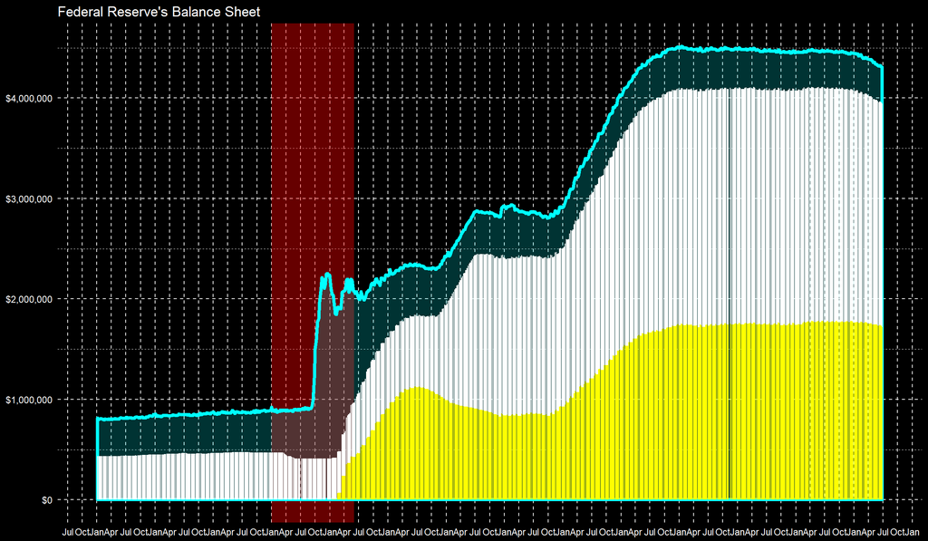

### RGDP Dy Graphic

[interactive chart not shown]

### Civilian Unemployment Rate

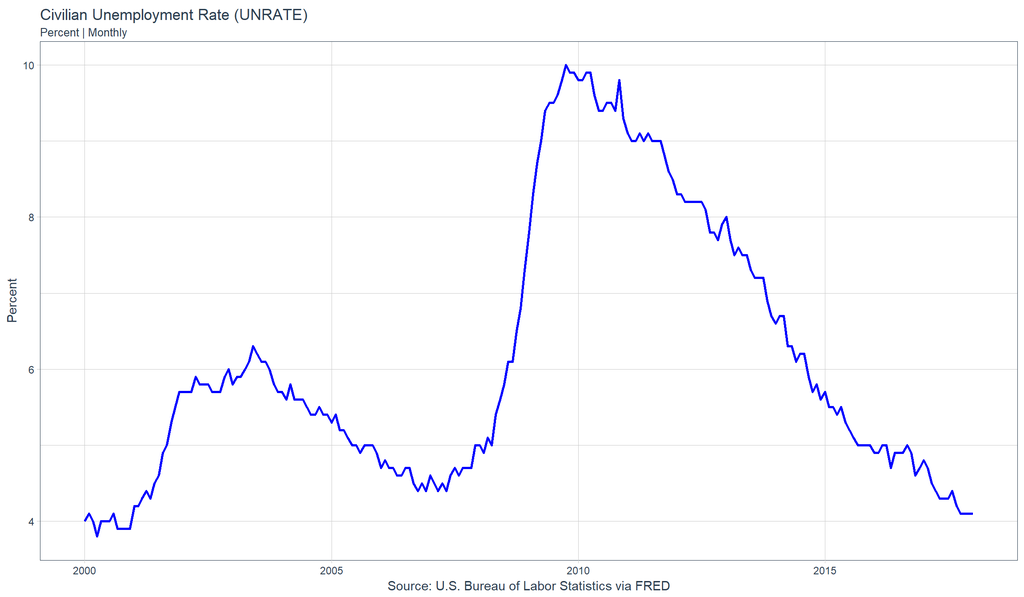

### Industrial Production Index

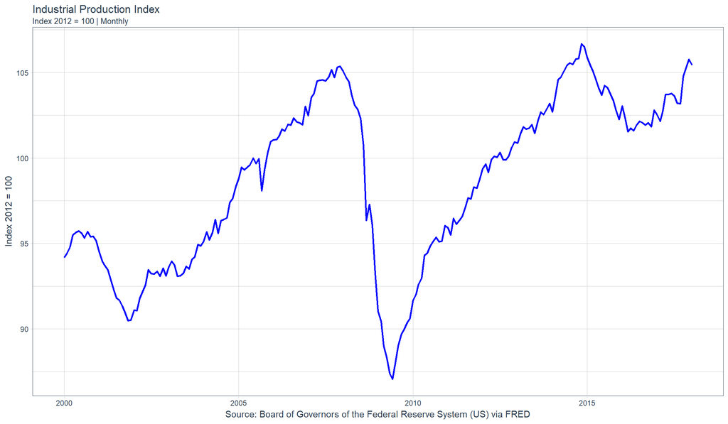

### Nonfarm Payrolls

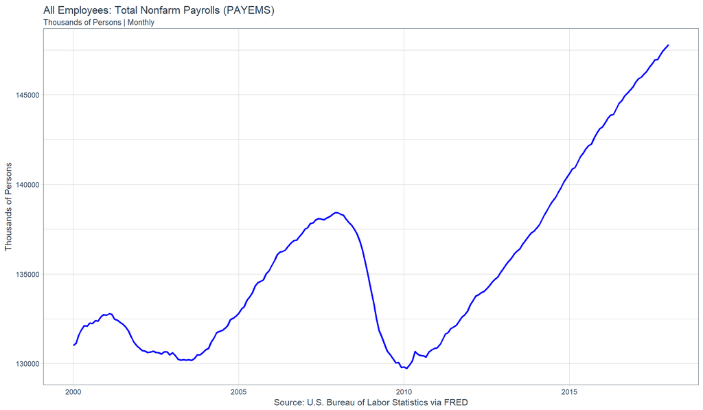

### Federal Funds Rate

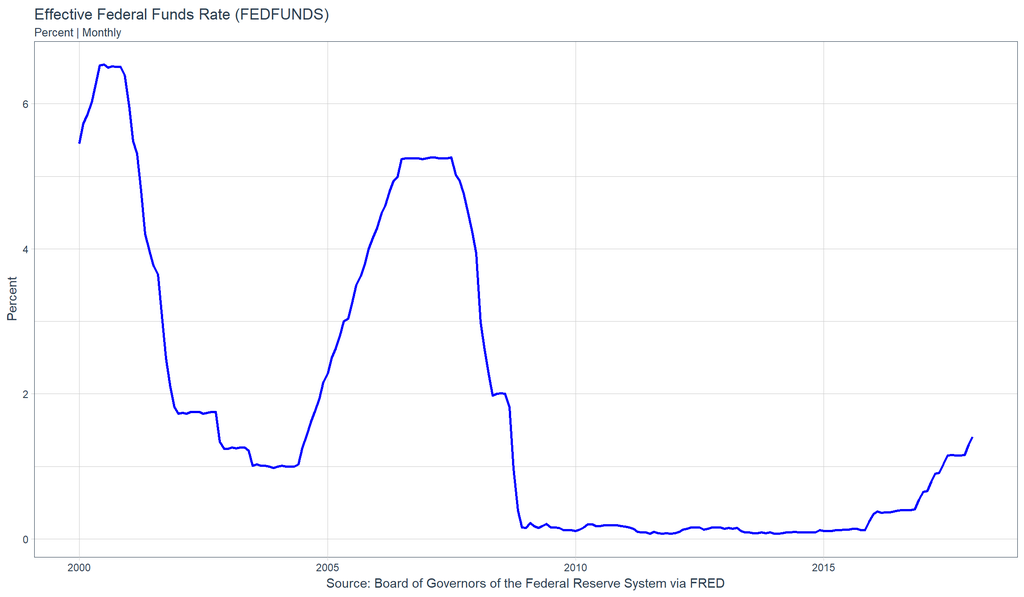

### DyGraphic

[interactive chart not shown]

**What is M3**

- M3 is a measure of the money supply that includes M2 as well as large time deposits, institutional money market funds, short-term repurchase agreements and other liquid assets
- The M3 measurement includes assets that are less liquid than other components of the money supply and are referred to as “near, near money,” which are more closely related to the finances of larger financial institutions and corporations than to those of small businesses and individuals.

**Calculating M3 and Its Importance**

- Each M3 component is given equal weight during calculation. For example, M2 and large time deposits are treated the same and aggregated without any adjustments. While this does create a simplified calculation, it assumes that each component of M3 affects the economy the same way. This can be considered a shortcoming of this measurement of the money supply.
- Since 2006, M3 is no longer tracked by the U.S. central bank, the Federal Reserve (Fed). The Fed did not use M3 in its monetary policy decisions even before 2006. The additional less liquid components of M3 did not seem to convey more economic information than was already captured by the more liquid components of M2.